# analysis survey winning team

2026-04-01

```r
library(readxl)
library(dplyr)
```

```r
library(ggplot2)

data <- read_excel("C:\\Users\\20253667\\OneDrive - TU Eindhoven\\Documents\\BRM1 Survey AI use (1-49).xlsx")

subset_data <- data[1:49, ]

clean <- function(x) {
  trimws(tolower(x))
}

scale_map <- c(
  "strongly dissagree" = 1,
  "disagree" = 2,
  "neutral" = 3,
  "agree" = 4,
  "strongly agree" = 5
)

q1 <- eval(parse(text = subset_data[ ,8]))
q2 <- eval(parse(text = subset_data[ ,9]))
q3 <- eval(parse(text = subset_data[ ,10]))

q1_num <- scale_map[clean(q1)]
q2_num <- scale_map[clean(q2)]
q3_num <- scale_map[clean(q3)]

unique(q1)
```

```
## [1] "Disagree"           "Agree"              "Strongly Dissagree"
## [4] "Neutral"            "Strongly agree"
```

```r
unique(q1_num)
```

```
## [1] 2 4 1 3 5
```

```r
q1
```

```
##  [1] "Disagree"           "Agree"              "Agree"
##  [4] "Strongly Dissagree" "Agree"              "Agree"
##  [7] "Neutral"            "Agree"              "Strongly agree"
## [10] "Neutral"            "Neutral"            "Agree"
## [13] "Neutral"            "Disagree"           "Neutral"
## [16] "Disagree"           "Strongly agree"     "Neutral"
## [19] "Agree"              "Agree"              "Agree"
## [22] "Disagree"           "Agree"              "Agree"
## [25] "Neutral"            "Neutral"            "Agree"
## [28] "Disagree"           "Agree"              "Agree"
## [31] "Agree"              "Disagree"           "Strongly Dissagree"
## [34] "Strongly Dissagree" "Neutral"            "Agree"
## [37] "Neutral"            "Strongly agree"     "Disagree"
## [40] "Neutral"            "Agree"              "Neutral"
## [43] "Disagree"           "Strongly Dissagree" "Neutral"
## [46] "Strongly Dissagree" "Disagree"           "Neutral"
## [49] "Agree"
```

```r
q1_num
```

```
##           disagree              agree              agree strongly dissagree
##                  2                  4                  4                  1
##              agree              agree            neutral              agree
##                  4                  4                  3                  4
##     strongly agree            neutral            neutral              agree
##                  5                  3                  3                  4
##            neutral           disagree            neutral           disagree
##                  3                  2                  3                  2
##     strongly agree            neutral              agree              agree
##                  5                  3                  4                  4
##              agree           disagree              agree              agree
##                  4                  2                  4                  4
##            neutral            neutral              agree           disagree
##                  3                  3                  4                  2
##              agree              agree              agree           disagree
##                  4                  4                  4                  2
## strongly dissagree strongly dissagree            neutral              agree
##                  1                  1                  3                  4
##            neutral     strongly agree           disagree            neutral
##                  3                  5                  2                  3
##              agree            neutral           disagree strongly dissagree
##                  4                  3                  2                  1
##            neutral strongly dissagree           disagree            neutral
##                  3                  1                  2                  3
##              agree
##                  4
```

```r
q2_rev <- 6 - q2_num

extroversion_score <- (q1_num + q2_rev + q3_num) / 3

extroversion_group <- ifelse(extroversion_score >= 3.5, "Extrovert",
                      ifelse(extroversion_score <= 2.5, "Introvert", NA))

scale <- c(
  "never" = 1,
  "rarely" = 2,
  "sometimes" = 3,
  "often" = 4,
  "very often" = 5
)

q4 <- eval(parse(text = subset_data[ ,11]))
q5 <- eval(parse(text = subset_data[ ,12]))
q6 <- eval(parse(text = subset_data[ ,13]))
q7 <- eval(parse(text = subset_data[ ,14]))

q4_num <- scale[clean(q4)]
q5_num <- scale[clean(q5)]
q6_num <- scale[clean(q6)]
q7_num <- scale[clean(q7)]

ai_usage_score <- (q4_num + q5_num + q6_num + q7_num) / 4

usage_group <- ifelse(ai_usage_score >= median(ai_usage_score, na.rm = TRUE), "Active AI User", "Low AI User")

q8 <- as.character(subset_data[ ,15])
q9 <- as.character(subset_data[ ,16])
q10 <- as.character(subset_data[ ,17])
q11 <- as.character(subset_data[ ,18])

q8 <- eval(parse(text = subset_data[ ,15]))
q9 <- eval(parse(text = subset_data[ ,16]))
q10 <- eval(parse(text = subset_data[ ,17]))
q11 <- eval(parse(text = subset_data[ ,18]))

q8_num <- scale_map[clean(q8)]
q9_num <- scale_map[clean(q9)]
q10_num <- scale_map[clean(q10)]
q11_num <- scale_map[clean(q11)]

reading_compr_score <- (q8_num + q9_num + q10_num + q11_num) / 4

active_data <- subset_data[usage_group == "Active AI User", ]

plot_data <- data.frame(
  extroversion_group = extroversion_group,
  reading_compr_score = reading_compr_score,
  usage_group = usage_group
)

plot_data <- plot_data[plot_data$usage_group == "Active AI User", ]
plot_data <- plot_data[!is.na(plot_data$extroversion_group), ]

summary(plot_data)
```

```
##  extroversion_group reading_compr_score usage_group
##  Length:11          Min.   :2.250       Length:11
##  Class :character   1st Qu.:2.625       Class :character
##  Mode  :character   Median :3.000       Mode  :character
##                     Mean   :3.071
##                     3rd Qu.:3.375
##                     Max.   :4.250
##                     NA's   :4
```

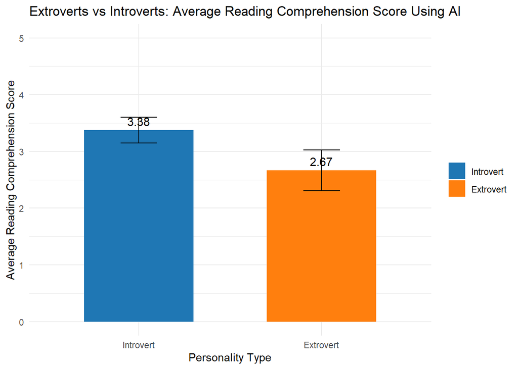

```r
plot_data$reading_compr_score <- as.numeric(plot_data$reading_compr_score)

plot_data$extroversion_group <- factor(plot_data$extroversion_group, levels = c("Introvert", "Extrovert"))

summary_data <- plot_data %>%
  group_by(extroversion_group) %>%
  summarise(
    mean_score = mean(reading_compr_score, na.rm = TRUE),
    se = sd(reading_compr_score, na.rm = TRUE)/sqrt(n())
  )

ggplot(summary_data, aes(x = extroversion_group, y = mean_score, fill = extroversion_group)) +
  geom_bar(stat = "identity", width = 0.6) +
  geom_errorbar(aes(ymin = mean_score - se, ymax = mean_score + se), width = 0.2) +
  geom_text(aes(label = round(mean_score, 2)), vjust = -0.5, size = 4) +
  scale_fill_manual(values = c("Introvert" = "#1f77b4", "Extrovert" = "#ff7f0e")) +
  ggtitle("Extroverts vs Introverts: Average Reading Comprehension Score Using AI") +
  theme_minimal() +
  labs(x = "Personality Type", y = "Average Reading Comprehension Score", fill = NULL) +
  ylim(0, 5)
```

First of all, we started with taking a part of the dataset since we are only interested in the rows from 1 to 49. Each question has its own column, that is why all the columns were pasted seperately into the different variables. For example, q1 <- eval(parse(text = subset_data[ ,8])) this gives the 8th column with parse(text= ) turning each string into R code and eval() turning it into an R object that can be worked with.

There are three seperate blocks of questions, with question 1 to 3 giving information on level of extroversion, question 4 to 7 about AI usage and question 8 to 11 on reading comprehension. In each block of questions, the answers were turned into numbers and the average was calculated. For question 4 to 7 about AI usage this gives us either Active AI User or Low AI User, because for this research we are not interested in Low AI Users. Also those we did not fall clearly into the category of extrovert or introvert (3.5 > score > 2.5) were excluded.

Then plot data was made taking the mean of reading comprehension and setting extroversion group to either introvert or extrovert, with this data a bar chart was made. The bar chart shows the average reading comprehension scores for introverts and extroverts among active AI users. Each bar represents the group mean, with error bars indicating the standard error of the mean. This provides a visual comparison of the reading comprehension performance between the two personality groups.